# Machine Learning for Single Cell Transcriptomics

Christopher Yau

2023-01-28

# Introduction

This practical is complementary to the lecture on *Machine Learning for Single Cell Transcriptomics* and is intended to support your learning on:

- dimensionality reduction (for visualisation)
- clustering

The practical is formed of two parts, the first will be done in-class, but the second can be undertaken in your own time.

# Pre-requisites

You will require the following R libraries:

```r
# CRAN libraries, use install.packages(...)
library(ggplot2)
library(cowplot)
library(Rtsne)
library(reshape2)
library(umap)
library(igraph)
library(ggheatmap)
library(RColorBrewer)

# Available via Github
##devtools::install_github("sctyner/geomnet")
library(geomnet)
```

For this practical it is very important to set the *seed* for the random number generator, otherwise your results will change everytime you re-run the whole script.

```r
# set the random number seed
set.seed(231343)
```

We will also define our own custom plotting function which we will make use of later:

```r
myplot2d <- function(dat, xax, yax, label) {
  plt = ggplot(dat, aes(x={{xax}}, y={{yax}}, color={{label}}))
  plt = plt + geom_point()
  plt = plt + theme_bw() + coord_fixed(ratio = 1)
  return(plt)
}
```

# Simulating data

We are first going to simulate some artificial gene expression data. It will be very artificial but the purpose is to understand the functionality of the algorithms that we will apply to the data rather than to generate the most realistic data possible.

## Setup

First, we will define the number of genes and cells we want to simulate data for and then create an empty matrix `X` containing zeros that will eventually contain our simulated data:

```r
G = 20 # number of genes
N = 100 # number of cells

# create an G x N matrix of zeros to store our simulated gene expression values
X = matrix(0, G, N)

# create gene names for the rows of the matrix X, these will be of the form GENEXX
gene_names <- c(sprintf("GENE%02d", seq(1,G)))
rownames(X) <- gene_names

# create cells names for the columns of the matrix X, these will be of the form CELLXX
cell_names <- c(sprintf("CELL%02d", seq(1,N)))
colnames(X) <- cell_names
```

Lets see a portion of the matrix `X` for the first 5 genes and 20 cells:

```r
print(X[1:5, 1:20])
```

```
##        CELL01 CELL02 CELL03 CELL04 CELL05 CELL06 CELL07 CELL08 CELL09 CELL10
## GENE01      0      0      0      0      0      0      0      0      0      0
## GENE02      0      0      0      0      0      0      0      0      0      0
## GENE03      0      0      0      0      0      0      0      0      0      0
## GENE04      0      0      0      0      0      0      0      0      0      0
## GENE05      0      0      0      0      0      0      0      0      0      0
##        CELL11 CELL12 CELL13 CELL14 CELL15 CELL16 CELL17 CELL18 CELL19 CELL20
## GENE01      0      0      0      0      0      0      0      0      0      0
## GENE02      0      0      0      0      0      0      0      0      0      0
## GENE03      0      0      0      0      0      0      0      0      0      0
## GENE04      0      0      0      0      0      0      0      0      0      0
## GENE05      0      0      0      0      0      0      0      0      0      0
```

## Assigning cell types

Next we will create a series of artificial cell type labels. We will create a data frame to hold the information for each cell:

```r
CellInfo = data.frame(CellName=cell_names) # create a data frame
rownames(CellInfo) = cell_names # assign cell names to the rows of the data frame
print(CellInfo[1:5, ]) # print the first five rows of the data frame
```

```
## [1] "CELL01" "CELL02" "CELL03" "CELL04" "CELL05"
```

Now, we will assign cells to one of four cell types (A, B, C, D). There will be an uneven number of each type:

```r
CellInfo[1:20, "CellType"] = "A" # the first 20 cells will be of type A
CellInfo[21:30, "CellType"] = "B" # the next 10 cells will be of type B
CellInfo[31:50, "CellType"] = "C" # the next 20 cells will be of type C
CellInfo[51:100, "CellType"] = "D" # the next 50 cells will be of type D
print(CellInfo[1:5, ]) # print the first five rows of the data frame
```

```
##        CellName CellType
## CELL01   CELL01        A
## CELL02   CELL02        A
## CELL03   CELL03        A
## CELL04   CELL04        A
## CELL05   CELL05        A
```

## Simulated expression values

For the first five genes, we will make these nuisance genes that give no information about cell type:

```r
for ( g in 1:5 ) {
  X[g, ] = rnorm(N, mean = 0, sd = 1) # can you work out what this does?
}
```

For the next five genes, we will make expression of these genes specific to cell types A and B:

```r
for ( g in 6:10 ){
  loc = which( CellInfo$"CellType" == "A" | CellInfo$"CellType" == "B" )
  n_loc = length(loc)
  X[g, loc] = rnorm(n_loc, mean = 2, sd = 1)

  loc = which( CellInfo$"CellType" != "A" & CellInfo$"CellType" != "B" )
  n_loc = length(loc)
  X[g, loc] = rnorm(n_loc, mean = 0, sd = 1)
}
```

With the next five genes, we will make expression of these genes specific to cell type C:

```r
for ( g in 11:15 ){

  loc = which( CellInfo$"CellType" == "C" )
  n_loc = length(loc)
  X[g, loc] = rnorm(n_loc, mean = 2, sd = 1)

  loc = which( CellInfo$"CellType" != "C" )
  n_loc = length(loc)
  X[g, loc] = rnorm(n_loc, mean = 0, sd = 1)

}
```

Finally, the last five genes will be specific to cell type D:

```r
for ( g in 16:20 ){

  loc = which( CellInfo$"CellType" == "D" )
  n_loc = length(loc)
  X[g, loc] = rnorm(n_loc, mean = 5, sd = 3)

  loc = which( CellInfo$"CellType" != "D" )
  n_loc = length(loc)
  X[g, loc] = rnorm(n_loc, mean = 0, sd = 1)
}
```

Now that we have done this, let us create a heatmap to display the matrix of gene expression values you have simulated:

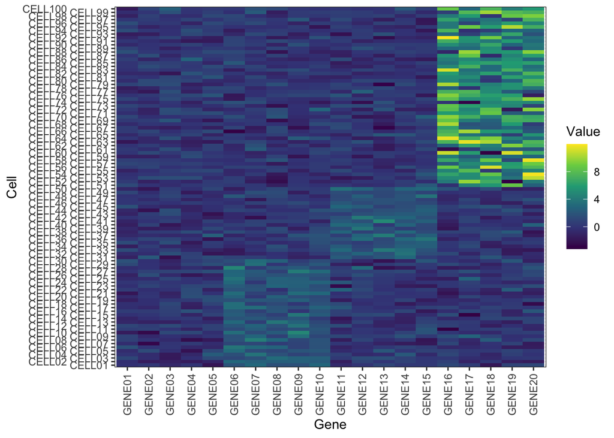

```r
X_dat = melt(X)
colnames(X_dat) <- c("Gene", "Cell", "Value")

plt = ggplot(X_dat, aes(x=Gene, y=Cell, fill=Value))
plt = plt + geom_tile()
plt = plt + theme_bw() + scale_fill_viridis_c()
plt = plt + theme(axis.text.x = element_text(angle = 90, vjust = 0.5, hjust=1)) +
  scale_y_discrete(guide = guide_axis(n.dodge = 2))

print(plt)
```

**Question:** Can you understand how the patterns you see in the heatmap relate to the gene expression of the four cell types you have simulated?

**Question:** Can you plot some histograms for each gene to see the distribution of expression values across the cells?

# Dimensionality reduction

In this section, we are going to use the data that you simulated and apply different approaches for dimensionality reduction and visualisation. You may have prior familiarity with some of these methods. The purpose of this exercise is to examine the properties of these methods, how their output varies as a function of key parameters and the implications for interpretation. As you have simulated the data, you know the exact nature of the data and how methods should *ideally* behave. It is generally not possible to do this with real data sets.

## Principal Components Analysis (PCA)

We will first apply PCA to your simulated dataset. We will use the `prcomp` function:

```r
pca_out = prcomp(X, center=TRUE, scale=TRUE, rank.=10)
```

We used the options `center` and `scale` and set these to true which makes the PCA first centre and scale the input data. This is necessary for the `prcomp` function because internally it uses *singular value decomposition* to compute the principal components and the output may not be correct without centering and scaling.

Next, we need to extract the coordinates of each cell under the three principal components and store these in our `CellInfo` data frame. These projections are contained in the output under `rotation` for this particular function. Note that the projection maybe referred to by another name in different implementations of PCA due to different terminologies in different fields for the same method:

```r
CellInfo$PC1 = pca_out$rotation[, 1]
CellInfo$PC2 = pca_out$rotation[, 2]
CellInfo$PC3 = pca_out$rotation[, 3]
```

PCA has the nice property that it directly gives us the *variance explained* by each principal component, i.e. how much of the variability of the data occurs in the direction of each principal component. The principal components are ordered such that the first principal component (PC1) explains the most variance, followed by PC2, PC3, etc.

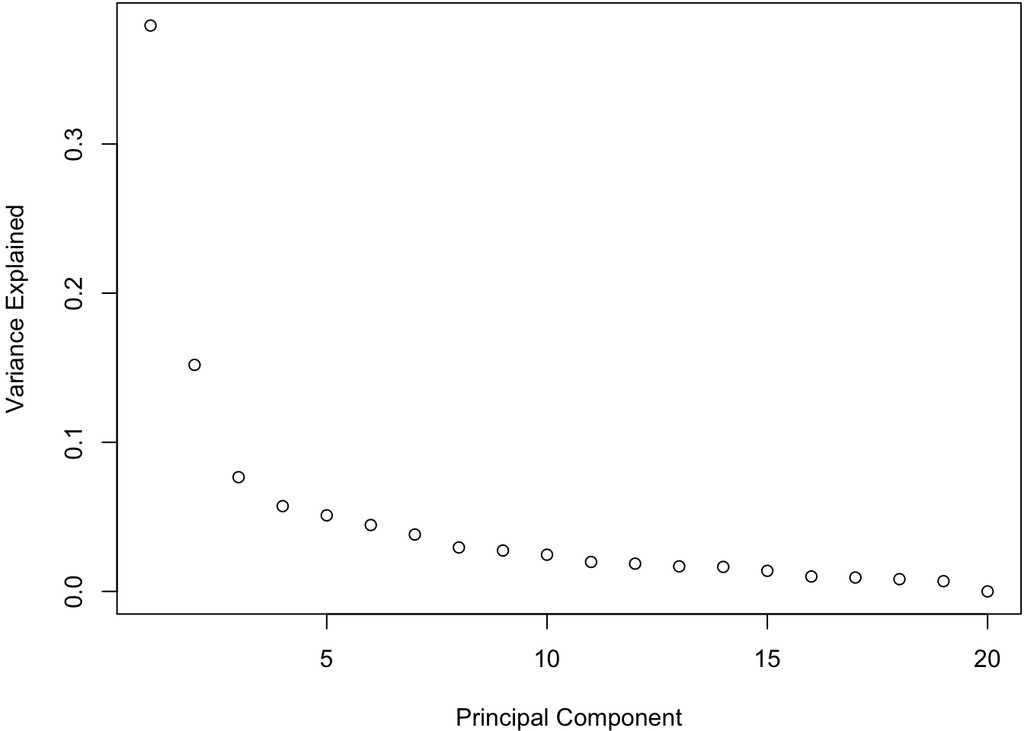

```r
par(mar = c(4, 4, 0.1, 0.1))  # reduce the amount of white space around plots
plot(1:length(pca_out$sdev), pca_out$sdev^2/sum(pca_out$sdev^2),xlab="Principal Component", ylab="Variance Explained")
```

We will now plot the projection of the cells on to first two principal components:

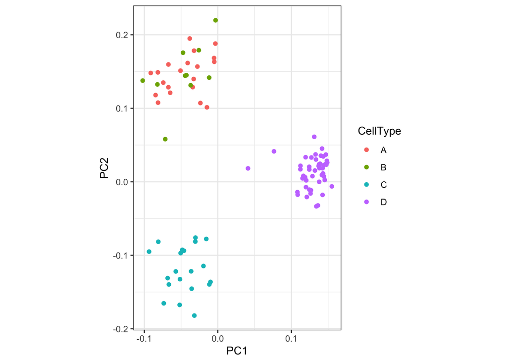

```r
plt_pca = myplot2d(CellInfo, PC1, PC2, CellType)
print(plt_pca)
```

You will see that some of the cell types separated in the first two principal components.

**Question:** Can you plot PC1 versus PC3? What do you notice? Can you look at other pairs principal components?

## t-Stochastic Neighbour Embedding (t-SNE)

We will now use t-SNE to visualise the data in two dimensions:

```r
tsne_out = Rtsne(t(X), dims = 2, perplexity = 5)
```

The algorithm uses an important parameter called `perplexity` which can be used to balance between the local and global structure of the data. The perplexity refers to the anticipated number of neighbours of each data point.

Next, lets store the output coordinates of each cell of the t-SNE analysis in our `CellInfo` data frame and plot this:

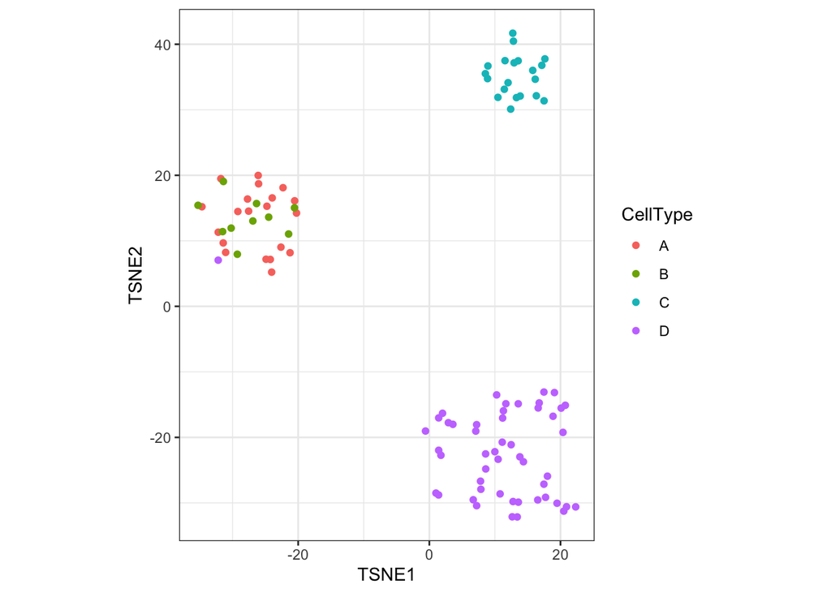

```r
CellInfo$TSNE1 = tsne_out$Y[, 1]
CellInfo$TSNE2 = tsne_out$Y[, 2]

plt_tsne = myplot2d(CellInfo, TSNE1, TSNE2, CellType)
plot(plt_tsne)
```

**Question:** Change the number of perplexity parameter for the t-SNE function? What happens to the clustering structure when you change the value?

## Uniform Manifold and Projection (UMAP)

Finally we will apply UMAP to visualise the data:

```r
umap_out = umap(t(X), n_neighbors = 5)
```

```
## as(<dgTMatrix>, "dgCMatrix") is deprecated since Matrix 1.5-0; do as(., "CsparseMatrix") instead
```

The UMAP function contains a parameter `n_neighbours` which acts like the perplexity parameter in t-SNE.

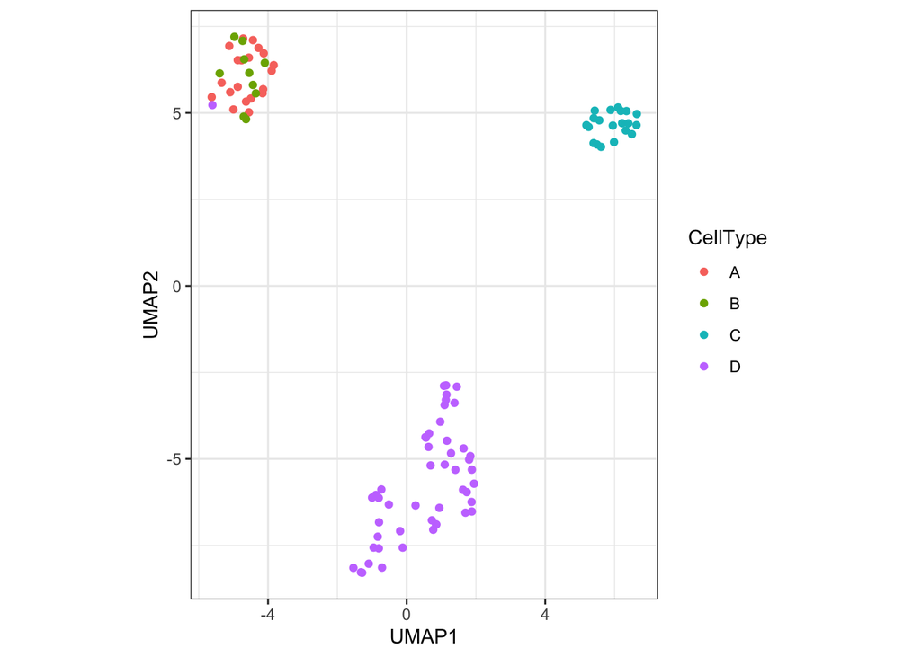

```r
CellInfo$UMAP1 = umap_out$layout[, 1]
CellInfo$UMAP2 = umap_out$layout[, 2]

plt_umap = myplot2d(CellInfo, UMAP1, UMAP2, CellType)
plot(plt_umap)
```

**Question:** Change the number of neighbours parameter for the UMAP function? What happens to the clustering structure when you change the value?

## Comparing visualisations

We will use the function `plot_grid` from the `cowplot` library to display all three visualisations together:

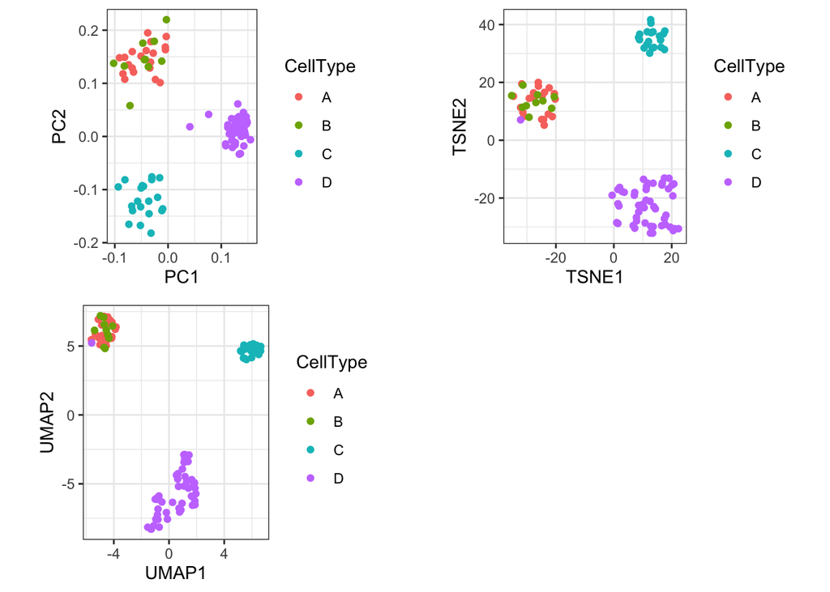

```r
plt_all = plot_grid(plt_pca, plt_tsne, plt_umap, nrow=2)
print(plt_all)
```

**Question:** How do the visualisations differ?

**Question:** What happens if you add the following code when producing your simulated data?

```
for ( g in 9:10 ){
  loc = which( CellInfo$"CellType" == "B" )
  n_loc = length(loc)
  X[g, loc] = rnorm(n_loc, mean = 4, sd = 1)
}
```

**Question:** Change the means and variance parameters in the normal distributions of the simulations and see how this changes the results? For example, what happens when you make some cell types “closer” (or further apart) in expression values? What if there are overlapping marker genes?

# Clustering

*This material is for self-learning and will not be explicitly covered during the practical session.*

This section illustrates an example of graph-based clustering. The example method will consist of two parts: (i) similarity graph construction and (ii) graph partitioning. We will use a nearest-neighbour approach for the first sub-problem and the Louvain clustering algorithm for the second.

## Distance matrix

First, we will compute the distance between every cell. To do this, we use the `dist` function:

```r
X_dist = as.matrix(dist(t(X)))
```

Now looks at the upper left corner of the computed distance matrix:

```r
print(X_dist[1:5, 1:5])
```

```
##          CELL01   CELL02   CELL03   CELL04   CELL05
## CELL01 0.000000 5.538157 5.303821 6.064473 5.358962
## CELL02 5.538157 0.000000 5.224699 6.237664 5.836106
## CELL03 5.303821 5.224699 0.000000 5.187720 5.313974
## CELL04 6.064473 6.237664 5.187720 0.000000 5.960236
## CELL05 5.358962 5.836106 5.313974 5.960236 0.000000
```

Each entry of the matrix gives the distance computed between the cell indicated by the corresponding row and column. The default distance measure is something known as the Euclidean distance. You can use `?dist` to look up its definition and other distance functions.

## Nearest neighbour identification

We now wish to identify the `K` nearest neighbours of each cell. We will first define the variable `K` (set to 10 initially) and create a matrix to hold the nearest neighbour information of each cell:

```r
K = 10 # find nearest neighbours
nearest_neighbours = matrix(0, N*(K-1), 3) # matrix of nearest neighbours`
```

The `nearest_neighbours` matrix has `N*(K-1)` rows because each of the `N` cells can have `K-1` neighbours which are not itself. There are three columns to denote the original cell, its neighbour and the distance between the two. Later, this information will be used to create a similarity raph.

First, we need to identify the neighbours of each cell. We will do this by creating a loop that goes through each cell, examines the distances to each of the `N-1` other cells and finds the `K` smallest distances (corresponding to the nearest neighbours).

```r
count = 1 # counter variable

# for each cell i
for ( i in 1:N ) {

  # sort the distances of the other cells to cell i
  sort_out = sort( X_dist[i, ], index.return=TRUE )

  # loop through the K-1 nearest neighbours and record their identity and the distance to them
  # we go from k=2 because the closest neighbour will be itself
  for (k in 2:K) {
    nearest_neighbours[count, 1] = i
    nearest_neighbours[count, 2] = sort_out$ix[k]
    nearest_neighbours[count, 3] = sort_out$x[k]
    count = count + 1
  }

}
```

We will convert the nearest neighbour matrix into a data frame and name the columns:

```r
edges <- as.data.frame(nearest_neighbours)
colnames(edges) <- c("from", "to", "weight")
```

We will use the function `graph_from_data_frame` to create a similarity graph from the nearest neighbour information and plot it:

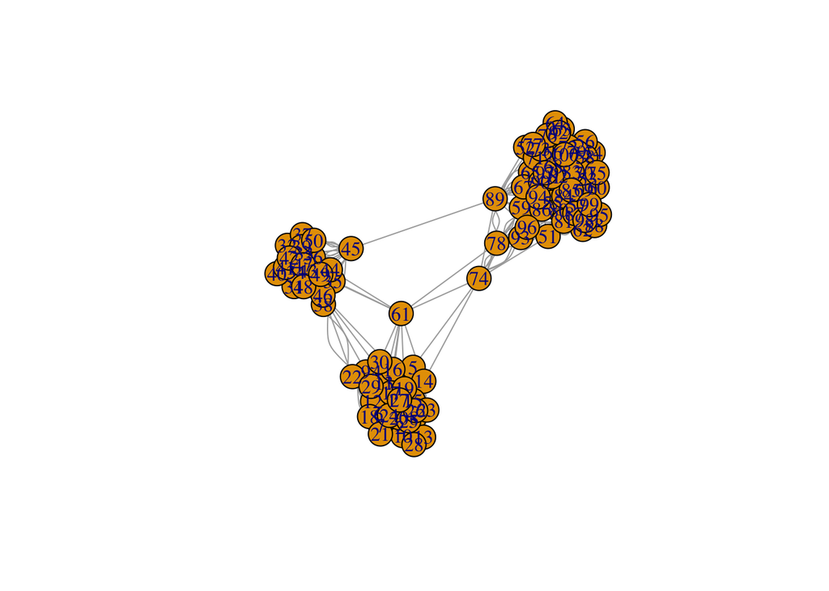

```r
data_graph = graph_from_data_frame(edges, directed=FALSE)
plot(data_graph)
```

**Question:** Visually, can you see how the similarity graph compares to the true clustering of the data?

## Graph partitioning

We will now use Louvain clustering to partition the graph into clusters:

```r
lc = cluster_louvain(data_graph, resolution = 0.1)
```

The function `cluster_louvain` contains a parameter `resolution` which controls the sizes of the communities or clusters it creates. Let’s create a plot comparing the true and estimated clustering structure:

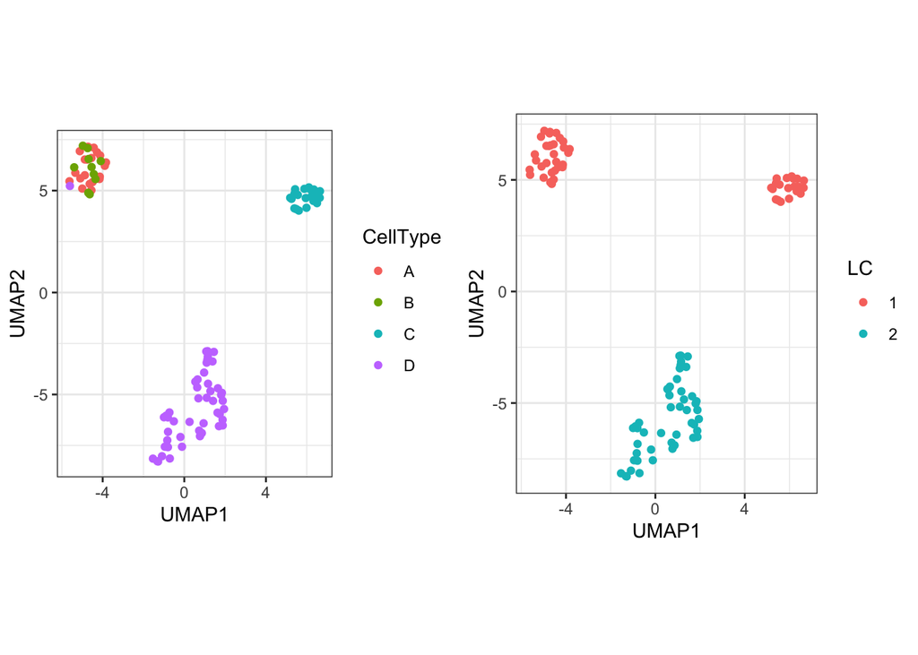

```r
CellInfo$LC = factor(lc$membership)
plt_umap_cluster = myplot2d(CellInfo, UMAP1, UMAP2, LC)
plt_umap_all = plot_grid(plt_umap, plt_umap_cluster, nrow=1)
print(plt_umap_all)
```

**Question:** How many clusters has the procedure found? What happens if you change the number of nearest neighbours in the similarity graph computation? What about the resolution of the Louvain clustering?